# Assignment 2

Catherine Saint

9/10/2020

## Setup

First, I’ll load the two libraries I need for this assignment.

```r
library(tidyverse)
```

```r
library(ggplot2)
```

Then, I’ll read the dataset I created for Assignment 1 and attach it to the search path so that I can refer to the variables in it without specifying which dataframe they’re in.

```r
tract_data <- read_csv("tractLosAngelesCA2018.csv")
attach(tract_data)
```

## Assignment Instructions

For each continuous variable in your dataset, calculate the sample mean, the sample standard deviation, the 95-percent confidence interval for the population mean, and the interquartile range. Create a histogram to illustrate the distribution of each variable and describe the distribution in a sentence or two.

For each categorical variable in your dataset, calculate the 95-percent confidence interval for the proportion of the population in each category.

### List of variables (from Assignment 1):

1. Median Age (continuous) : med_ageE
2. Part of the total population unemployed in civilian labor force (age 16 years and above) (continuous): pct_unemp_labor
3. Part of the total population who are high school graduates (or equivalent) in labor force (continuous): pct_hs_grad
4. Majority race of the population (categorical) : maj_race_tract
5. Whether the majority of the population is foreign born or not(categorical): maj_foreign

## Distribution of Continuous Variables

### Descriptive statistics

First I calculate summary statistics.

```r
age_summary <-  summary(med_ageE)
age_sd <- sd(med_ageE, na.rm = TRUE)
age_pop_mean_int <- t.test(med_ageE)
unemp_summary <- summary(pct_unemp_labor)
unemp_sd <- sd(pct_unemp_labor, na.rm = TRUE)
unemp_pop_mean_int <- t.test(pct_unemp_labor)
hs_summary <- summary(pct_hs_grad)
hs_sd <- sd(pct_hs_grad, na.rm = TRUE)
hs_pop_mean_int <- t.test(pct_hs_grad)
```

And display them in a formatted table:

```r
summary_table <- tibble(
  Statistic = c("Sample mean",
                "Median",
                "Standard deviation",
                "Interquartile range",
                "Population mean (95% confidence)"),
  `Median age (years)` = c(prettyNum(age_summary["Mean"], digits=3),
                           age_summary["Median"],
                           prettyNum(age_sd, digits = 3),
                           paste(age_summary["1st Qu."],"to",
                                 age_summary["3rd Qu."]),
                           paste(prettyNum(age_pop_mean_int$conf.int[1],
                                           digits=3), "to",
                                 prettyNum(age_pop_mean_int$conf.int[2],
                                               digits=3))),
  `Percent unemployed` = c(paste(prettyNum(unemp_summary["Mean"]*100,
                                           digits=3),"%"),
                           paste(prettyNum(unemp_summary["Median"]*100,
                                           digits=3),"%"),
                           paste(prettyNum(unemp_sd*100, digits=3),"%"),
                           paste(prettyNum(unemp_summary["1st Qu."]*100,
                                           digits=3),
                                 "% to",
                                 prettyNum(unemp_summary["3rd Qu."]*100,
                                           digits=3), "%"),
                           paste(prettyNum(unemp_pop_mean_int$conf.int[1]*100,
                                           digits=3), "% to",
                                 prettyNum(unemp_pop_mean_int$conf.int[2]*100,
                                           digits=3), "%")),
  `Percent high-school graduate workers` =
    c(paste(prettyNum(hs_summary["Mean"]*100, digits=3),"%"),
      paste(prettyNum(hs_summary["Median"]*100, digits=3),"%"),
      paste(prettyNum(hs_sd*100, digits=3),"%"),
      paste(prettyNum(hs_summary["1st Qu."]*100, digits=3), "% to",
            prettyNum(hs_summary["3rd Qu."]*100, digits=3), "%"),
      paste(prettyNum(hs_pop_mean_int$conf.int[1]*100, digits=3), "% to",
            prettyNum(hs_pop_mean_int$conf.int[2]*100, digits=3), "%")))
knitr::kable(summary_table,
             caption = "Characteristics of census tracts in Los Angeles County")
```

Characteristics of census tracts in Los Angeles County

| Statistic | Median age (years) | Percent unemployed | Percent high-school graduate workers |
| --- | --- | --- | --- |
| Sample mean | 37.1 | 3.55 % | 8.4 % |
| Median | 36.4 | 3.32 % | 8.67 % |
| Standard deviation | 6.59 | 1.71 % | 4.25 % |
| Interquartile range | 32.4 to 41.3 | 2.38 % to 4.51 % | 5.69 % to 11 % |
| Population mean (95% confidence) | 36.8 to 37.3 | 3.48 % to 3.62 % | 8.23 % to 8.58 % |

### Histograms

Now, I’ll create histogram for each of these three distributions.

#### Median age

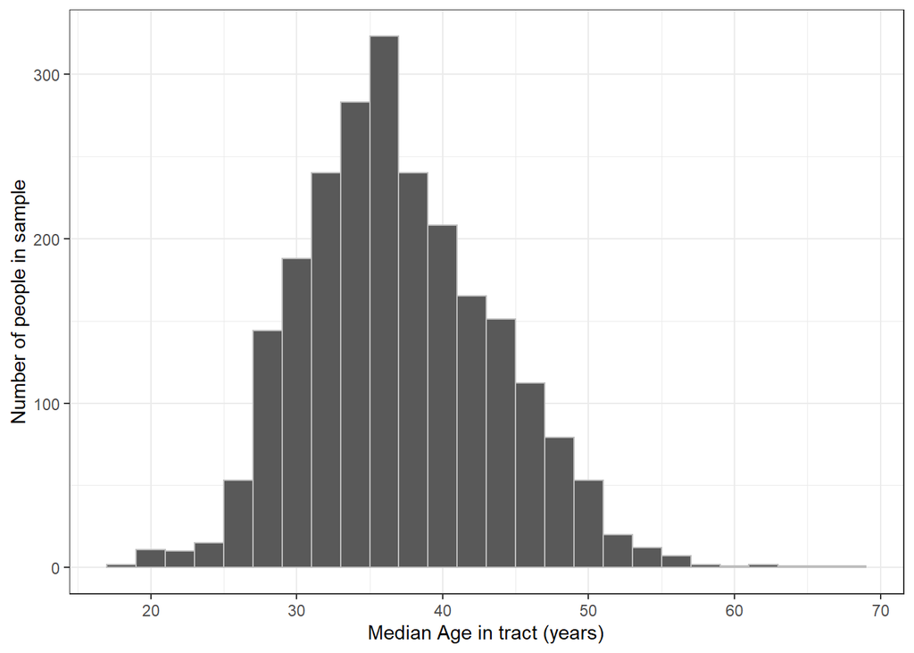

```r
ggplot(tract_data, aes(x = med_ageE)) +
  geom_histogram(color = "gray", binwidth = 2) +
  theme_bw() +
  scale_x_continuous(name = "Median Age in tract (years)") +
  scale_y_continuous(name = "Number of people in sample")
```

The distribution of age looks relatively normal, with a slight skew to the right. The median value is less than the corresponding mean value, because the outliers are located further out along the x-axis, where age increases.

#### Unemployment

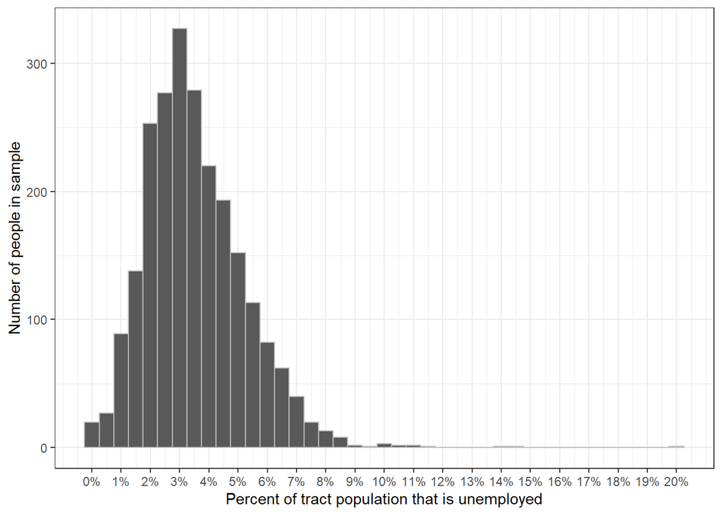

```r
ggplot(tract_data, aes(x = pct_unemp_labor)) +
  geom_histogram(color = "gray", binwidth = 0.005) +
  theme_bw() +
  scale_x_continuous(name = "Percent of tract population that is unemployed",
                     breaks = breaks <- seq(0, 0.2, by = 0.01),
                     labels = paste(breaks*100, "%", sep = "")) +
  scale_y_continuous(name = "Number of people in sample")
```

The distribution of unemployment is positively skewed with a long tail. Outliers around 20% bring the average of the distribution up, with most of the observations concentrated to the left.

#### Worker education

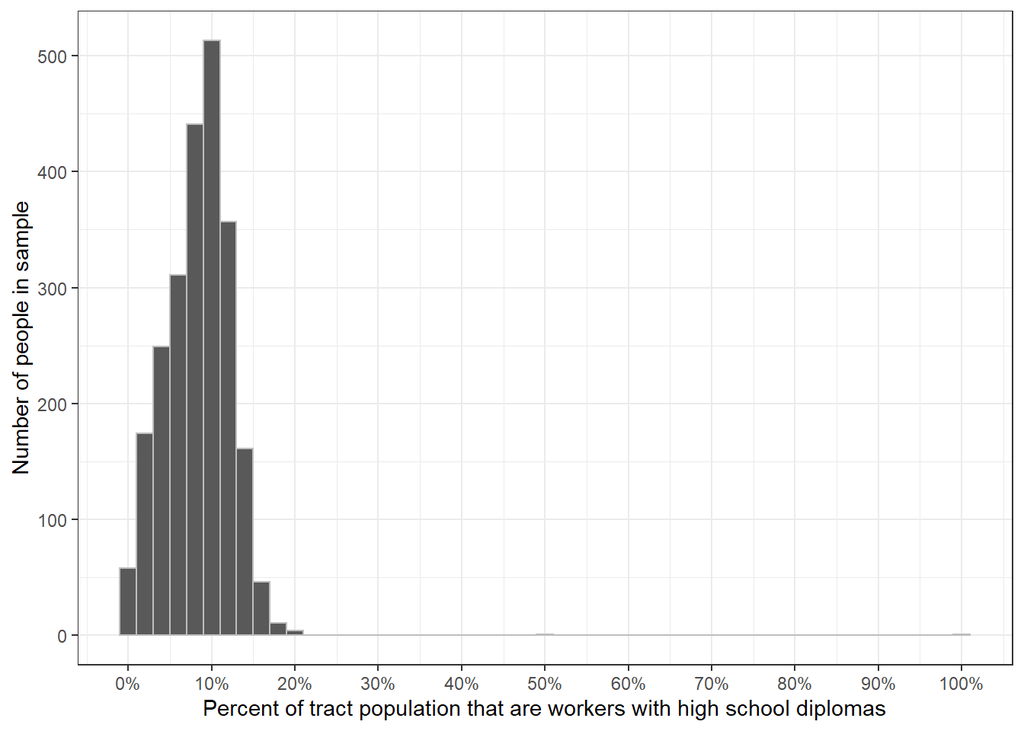

```r
ggplot(tract_data, aes(x = pct_hs_grad)) +
  geom_histogram(color = "gray", binwidth = 0.02) +
  theme_bw() +
  scale_x_continuous(name =
    "Percent of tract population that are workers with high school diplomas",
                     breaks = breaks <- seq(0, 1, by = 0.1),
                     labels = paste(breaks*100, "%", sep = "")) +
  scale_y_continuous(name = "Number of people in sample")
```

The data skews negatively to the left. Although there are outliers located to the right of the mean and median, there still remains a greater number of observations closer to 0%, bringing down the average.

## Distribution of Categorical Variables

I’ll show two tables, one showing the proportions of each category for each of my categorical variables.

### Race/Ethnicity

First I’ll do a t-test for each individual race/ethnicity category.

```r
nh_black <- t.test (maj_race_tract == "nh_black")
hs_latino <- t.test (maj_race_tract == "hs_latino")
no_majority <- t.test (maj_race_tract == "no_majority")
nh_white <- t.test (maj_race_tract == "nh_white")
nh_asian <- t.test (maj_race_tract == "nh_asian")
```

Then I’ll create a formatted table with proportions and confidence intervals

```r
race_shares <- tibble(`Majority Race` = c("Hispanic/Latino",
                                  "White (not Hispanic/Latino)",
                                  "No Majority",
                                  "Asian (not Hispanic/Latino)",
                                  "Black (not Hispanic/Latino)"),
                 `Sample proportion` = c(paste(prettyNum(hs_latino$estimate*100,
                                                         digits = 3), "%"),
                                         paste(prettyNum(nh_white$estimate*100,
                                                         digits = 3), "%"),
                                         paste(prettyNum(no_majority$estimate*100,
                                                         digits = 3), "%"),
                                         paste(prettyNum(nh_asian$estimate*100,
                                                         digits = 3), "%"),
                                         paste(prettyNum(nh_black$estimate*100,
                                                         digits = 3), "%")),
                 `95-percent confidence interval` = c(
                   paste(prettyNum(hs_latino$conf.int[1]*100, digits=3),
                         "% to ",
                         prettyNum(hs_latino$conf.int[2]*100, digits=3),
                         "%", sep=""),
                   paste(prettyNum(nh_white$conf.int[1]*100, digits=3),
                         "% to ",
                         prettyNum(nh_white$conf.int[2]*100, digits=3),
                         "%", sep=""),
                   paste(prettyNum(no_majority$conf.int[1]*100, digits=3),
                         "% to ",
                         prettyNum(no_majority$conf.int[2]*100, digits=3),
                         "%", sep=""),
                   paste(prettyNum(nh_asian$conf.int[1]*100, digits=3),
                         "% to ",
                         prettyNum(nh_asian$conf.int[2]*100, digits=3),
                         "%", sep=""),
                   paste(prettyNum(nh_black$conf.int[1]*100, digits=3),
                         "% to ",
                         prettyNum(nh_black$conf.int[2]*100, digits=3),
                         "%", sep="")))


knitr::kable(race_shares, caption = "Census tracts in Los Angeles County")
```

Census tracts in Los Angeles County

| Majority Race | Sample proportion | 95-percent confidence interval |
| --- | --- | --- |
| Hispanic/Latino | 46.2 % | 44.2% to 48.2% |
| White (not Hispanic/Latino) | 23.2 % | 21.5% to 24.9% |
| No Majority | 23 % | 21.3% to 24.7% |
| Asian (not Hispanic/Latino) | 5.29 % | 4.38% to 6.19% |
| Black (not Hispanic/Latino) | 2.26 % | 1.66% to 2.86% |

### Nativity

First I’ll do a t-test for each individual nativity category.

```r
maj_for_born <- t.test(maj_foreign)
maj_nat_born <- t.test(!maj_foreign)
```

Then I’ll display the results in a formatted table.

```r
for_shares <- tibble(`Majority nativity` = c("Native born","Foreign born"),
                     `Sample proportion` =
                       c(paste(prettyNum(maj_nat_born$estimate*100,
                                         digits = 3), "%"),
                         paste(prettyNum(maj_for_born$estimate*100,
                                         digits = 3), "%")),
                      `95-percent confidence interval` =
                        c(paste(prettyNum(maj_nat_born$conf.int[1]*100,
                                          digits = 3), "% to ",
                                prettyNum(maj_nat_born$conf.int[2]*100,
                                          digits = 3), "%"),
                         paste(prettyNum(maj_for_born$conf.int[1]*100,
                                          digits = 3), "% to ",
                                prettyNum(maj_for_born$conf.int[2]*100,
                                          digits = 3), "%")))
knitr::kable(for_shares, caption = "Census tracts in Los Angeles County")
```

Census tracts in Los Angeles County

| Majority nativity | Sample proportion | 95-percent confidence interval |
| --- | --- | --- |
| Native born | 88.3 % | 87 % to 89.6 % |
| Foreign born | 11.7 % | 10.4 % to 13 % |